# Risk Factor Analysis

## Outcome Variable

**Outcome Variable:** wasted

## Predictor Variables

**Intervention Variable:** predfeed36

**Adjustment Set:**

unadjusted

## Stratifying Variables

The analysis was stratified on these variable(s):

- agecat
- studyid
- country

## Data Summary

| agecat | studyid | country | predfeed36 | wasted | n_cell | n |
| --- | --- | --- | --- | --- | --- | --- |
| Birth | ki0047075b-MAL-ED | BANGLADESH | 1 | 0 | 59 | 208 |
| Birth | ki0047075b-MAL-ED | BANGLADESH | 1 | 1 | 10 | 208 |
| Birth | ki0047075b-MAL-ED | BANGLADESH | 0 | 0 | 115 | 208 |
| Birth | ki0047075b-MAL-ED | BANGLADESH | 0 | 1 | 24 | 208 |
| Birth | ki0047075b-MAL-ED | BRAZIL | 1 | 0 | 7 | 62 |
| Birth | ki0047075b-MAL-ED | BRAZIL | 1 | 1 | 0 | 62 |
| Birth | ki0047075b-MAL-ED | BRAZIL | 0 | 0 | 53 | 62 |
| Birth | ki0047075b-MAL-ED | BRAZIL | 0 | 1 | 2 | 62 |
| Birth | ki0047075b-MAL-ED | INDIA | 1 | 0 | 4 | 40 |
| Birth | ki0047075b-MAL-ED | INDIA | 1 | 1 | 0 | 40 |
| Birth | ki0047075b-MAL-ED | INDIA | 0 | 0 | 31 | 40 |
| Birth | ki0047075b-MAL-ED | INDIA | 0 | 1 | 5 | 40 |
| Birth | ki0047075b-MAL-ED | NEPAL | 1 | 0 | 0 | 25 |
| Birth | ki0047075b-MAL-ED | NEPAL | 1 | 1 | 1 | 25 |
| Birth | ki0047075b-MAL-ED | NEPAL | 0 | 0 | 23 | 25 |
| Birth | ki0047075b-MAL-ED | NEPAL | 0 | 1 | 1 | 25 |
| Birth | ki0047075b-MAL-ED | PERU | 1 | 0 | 57 | 218 |
| Birth | ki0047075b-MAL-ED | PERU | 1 | 1 | 0 | 218 |
| Birth | ki0047075b-MAL-ED | PERU | 0 | 0 | 156 | 218 |
| Birth | ki0047075b-MAL-ED | PERU | 0 | 1 | 5 | 218 |
| Birth | ki0047075b-MAL-ED | SOUTH AFRICA | 1 | 0 | 2 | 104 |
| Birth | ki0047075b-MAL-ED | SOUTH AFRICA | 1 | 1 | 0 | 104 |
| Birth | ki0047075b-MAL-ED | SOUTH AFRICA | 0 | 0 | 93 | 104 |
| Birth | ki0047075b-MAL-ED | SOUTH AFRICA | 0 | 1 | 9 | 104 |
| Birth | ki0047075b-MAL-ED | TANZANIA, UNITED REPUBLIC OF | 1 | 0 | 0 | 111 |
| Birth | ki0047075b-MAL-ED | TANZANIA, UNITED REPUBLIC OF | 1 | 1 | 0 | 111 |
| Birth | ki0047075b-MAL-ED | TANZANIA, UNITED REPUBLIC OF | 0 | 0 | 110 | 111 |
| Birth | ki0047075b-MAL-ED | TANZANIA, UNITED REPUBLIC OF | 0 | 1 | 1 | 111 |
| Birth | ki1000109-EE | PAKISTAN | 1 | 0 | 2 | 6 |
| Birth | ki1000109-EE | PAKISTAN | 1 | 1 | 0 | 6 |

[output cut: 114 more lines]

The following strata were considered:

- agecat: 24 months, studyid: ki0047075b-MAL-ED, country: BANGLADESH
- agecat: 24 months, studyid: ki0047075b-MAL-ED, country: BRAZIL
- agecat: 24 months, studyid: ki0047075b-MAL-ED, country: INDIA
- agecat: 24 months, studyid: ki0047075b-MAL-ED, country: NEPAL
- agecat: 24 months, studyid: ki0047075b-MAL-ED, country: PERU
- agecat: 24 months, studyid: ki0047075b-MAL-ED, country: SOUTH AFRICA
- agecat: 24 months, studyid: ki0047075b-MAL-ED, country: TANZANIA, UNITED REPUBLIC OF
- agecat: 24 months, studyid: ki1000109-EE, country: PAKISTAN
- agecat: 24 months, studyid: ki1113344-GMS-Nepal, country: NEPAL
- agecat: 24 months, studyid: ki1148112-LCNI-5, country: MALAWI
- agecat: 24 months, studyid: kiGH5241-JiVitA-3, country: BANGLADESH
- agecat: 24 months, studyid: kiGH5241-JiVitA-4, country: BANGLADESH
- agecat: 6 months, studyid: ki0047075b-MAL-ED, country: BANGLADESH
- agecat: 6 months, studyid: ki0047075b-MAL-ED, country: BRAZIL
- agecat: 6 months, studyid: ki0047075b-MAL-ED, country: INDIA
- agecat: 6 months, studyid: ki0047075b-MAL-ED, country: NEPAL
- agecat: 6 months, studyid: ki0047075b-MAL-ED, country: PERU
- agecat: 6 months, studyid: ki0047075b-MAL-ED, country: SOUTH AFRICA
- agecat: 6 months, studyid: ki0047075b-MAL-ED, country: TANZANIA, UNITED REPUBLIC OF
- agecat: 6 months, studyid: ki1000109-EE, country: PAKISTAN
- agecat: 6 months, studyid: ki1000304b-SAS-FoodSuppl, country: INDIA
- agecat: 6 months, studyid: ki1113344-GMS-Nepal, country: NEPAL
- agecat: 6 months, studyid: ki1148112-LCNI-5, country: MALAWI
- agecat: 6 months, studyid: kiGH5241-JiVitA-3, country: BANGLADESH
- agecat: 6 months, studyid: kiGH5241-JiVitA-4, country: BANGLADESH
- agecat: Birth, studyid: ki0047075b-MAL-ED, country: BANGLADESH
- agecat: Birth, studyid: ki0047075b-MAL-ED, country: BRAZIL
- agecat: Birth, studyid: ki0047075b-MAL-ED, country: INDIA
- agecat: Birth, studyid: ki0047075b-MAL-ED, country: NEPAL
- agecat: Birth, studyid: ki0047075b-MAL-ED, country: PERU
- agecat: Birth, studyid: ki0047075b-MAL-ED, country: SOUTH AFRICA
- agecat: Birth, studyid: ki0047075b-MAL-ED, country: TANZANIA, UNITED REPUBLIC OF
- agecat: Birth, studyid: ki1000109-EE, country: PAKISTAN
- agecat: Birth, studyid: ki1113344-GMS-Nepal, country: NEPAL
- agecat: Birth, studyid: kiGH5241-JiVitA-3, country: BANGLADESH
- agecat: Birth, studyid: kiGH5241-JiVitA-4, country: BANGLADESH

### Dropped Strata

Some strata were dropped due to rare outcomes:

- agecat: Birth, studyid: ki0047075b-MAL-ED, country: BRAZIL
- agecat: Birth, studyid: ki0047075b-MAL-ED, country: INDIA
- agecat: Birth, studyid: ki0047075b-MAL-ED, country: NEPAL
- agecat: Birth, studyid: ki0047075b-MAL-ED, country: PERU
- agecat: Birth, studyid: ki0047075b-MAL-ED, country: SOUTH AFRICA
- agecat: Birth, studyid: ki0047075b-MAL-ED, country: TANZANIA, UNITED REPUBLIC OF
- agecat: Birth, studyid: ki1000109-EE, country: PAKISTAN
- agecat: 6 months, studyid: ki0047075b-MAL-ED, country: BANGLADESH
- agecat: 6 months, studyid: ki0047075b-MAL-ED, country: BRAZIL
- agecat: 6 months, studyid: ki0047075b-MAL-ED, country: INDIA
- agecat: 6 months, studyid: ki0047075b-MAL-ED, country: NEPAL
- agecat: 6 months, studyid: ki0047075b-MAL-ED, country: PERU
- agecat: 6 months, studyid: ki0047075b-MAL-ED, country: SOUTH AFRICA
- agecat: 6 months, studyid: ki0047075b-MAL-ED, country: TANZANIA, UNITED REPUBLIC OF
- agecat: 6 months, studyid: ki1000109-EE, country: PAKISTAN
- agecat: 6 months, studyid: ki1000304b-SAS-FoodSuppl, country: INDIA
- agecat: 6 months, studyid: ki1148112-LCNI-5, country: MALAWI
- agecat: 24 months, studyid: ki0047075b-MAL-ED, country: BRAZIL
- agecat: 24 months, studyid: ki0047075b-MAL-ED, country: INDIA
- agecat: 24 months, studyid: ki0047075b-MAL-ED, country: NEPAL
- agecat: 24 months, studyid: ki0047075b-MAL-ED, country: PERU
- agecat: 24 months, studyid: ki0047075b-MAL-ED, country: SOUTH AFRICA
- agecat: 24 months, studyid: ki0047075b-MAL-ED, country: TANZANIA, UNITED REPUBLIC OF
- agecat: 24 months, studyid: ki1000109-EE, country: PAKISTAN
- agecat: 24 months, studyid: ki1148112-LCNI-5, country: MALAWI

## Methods Detail

We’re interested in the causal parameters $E[Y_a]$ for all values of $a \in \mathcal{A}$. These parameters represent the mean outcome if, possibly contrary to fact, we intervened to set all units to have $A=a$. Under the randomization and positivity assumptions, these are identified by the statistical parameters $\psi_a=E_W[E_{Y|A,W}(Y|A=a,W)]$. In addition, we’re interested in the mean of $Y$, $E[Y]$ under no intervention (the observed mean). We will estimate these parameters by using SuperLearner to fit the relevant likelihood factors – $E_{Y|A,W}(Y|A=a,W)$ and $p(A=a|W)$, and then updating our likelihood fit using a joint TMLE.

For unadjusted analyses ($W=\{\}$), initial likelihoods were estimated using Lrnr_glm to estimate the simple $E(Y|A)$ and Lrnr_mean to estimate $p(A)$. For adjusted analyses, a small library containing Lrnr_glmnet, Lrnr_xgboost, and Lrnr_mean was used.

Having estimated these parameters, we will then use the delta method to estimate relative risks and attributable risks relative to a prespecified baseline level of $A$.

# Results Detail

## Results Plots

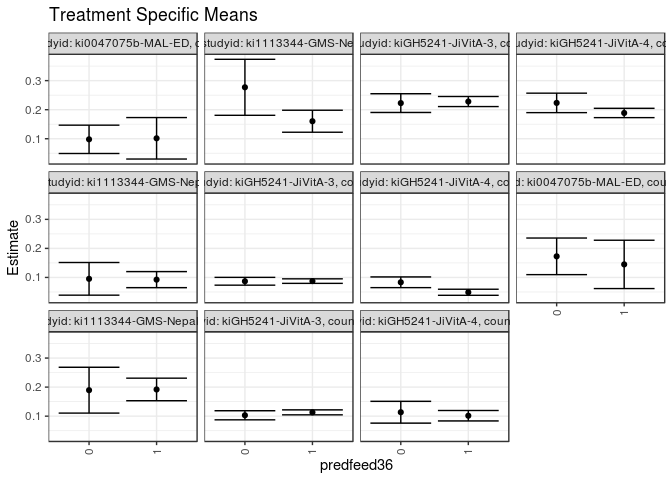

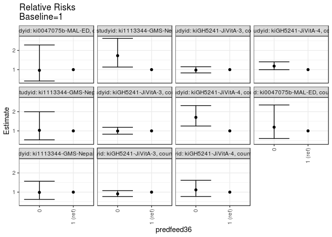

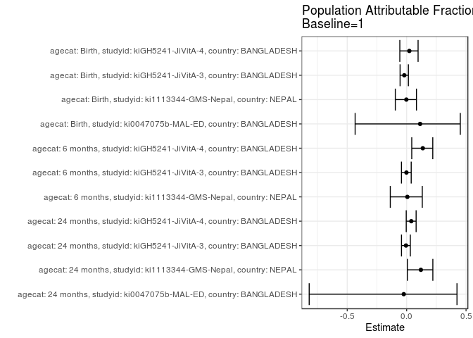

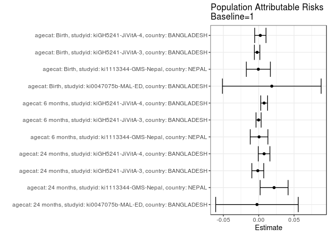

## Results Table

### Parameter: TSM

| agecat | studyid | country | intervention_level | baseline_level | estimate | ci_lower | ci_upper |
| --- | --- | --- | --- | --- | --- | --- | --- |
| Birth | ki0047075b-MAL-ED | BANGLADESH | 1 | NA | 0.1449275 | 0.0616655 | 0.2281896 |
| Birth | ki0047075b-MAL-ED | BANGLADESH | 0 | NA | 0.1726619 | 0.1096784 | 0.2356454 |
| Birth | ki1113344-GMS-Nepal | NEPAL | 1 | NA | 0.1919192 | 0.1530926 | 0.2307458 |
| Birth | ki1113344-GMS-Nepal | NEPAL | 0 | NA | 0.1894737 | 0.1105900 | 0.2683573 |
| Birth | kiGH5241-JiVitA-3 | BANGLADESH | 1 | NA | 0.1131041 | 0.1045247 | 0.1216834 |
| Birth | kiGH5241-JiVitA-3 | BANGLADESH | 0 | NA | 0.1030432 | 0.0874225 | 0.1186640 |
| Birth | kiGH5241-JiVitA-4 | BANGLADESH | 1 | NA | 0.1015169 | 0.0835805 | 0.1194533 |
| Birth | kiGH5241-JiVitA-4 | BANGLADESH | 0 | NA | 0.1135266 | 0.0760216 | 0.1510316 |
| 6 months | ki1113344-GMS-Nepal | NEPAL | 1 | NA | 0.0924171 | 0.0647589 | 0.1200752 |
| 6 months | ki1113344-GMS-Nepal | NEPAL | 0 | NA | 0.0952381 | 0.0390378 | 0.1514384 |
| 6 months | kiGH5241-JiVitA-3 | BANGLADESH | 1 | NA | 0.0874392 | 0.0796369 | 0.0952414 |
| 6 months | kiGH5241-JiVitA-3 | BANGLADESH | 0 | NA | 0.0867790 | 0.0733351 | 0.1002228 |
| 6 months | kiGH5241-JiVitA-4 | BANGLADESH | 1 | NA | 0.0488930 | 0.0384425 | 0.0593435 |
| 6 months | kiGH5241-JiVitA-4 | BANGLADESH | 0 | NA | 0.0833333 | 0.0649081 | 0.1017585 |
| 24 months | ki0047075b-MAL-ED | BANGLADESH | 1 | NA | 0.1014493 | 0.0300414 | 0.1728571 |
| 24 months | ki0047075b-MAL-ED | BANGLADESH | 0 | NA | 0.0979021 | 0.0490785 | 0.1467257 |
| 24 months | ki1113344-GMS-Nepal | NEPAL | 1 | NA | 0.1602210 | 0.1223920 | 0.1980500 |
| 24 months | ki1113344-GMS-Nepal | NEPAL | 0 | NA | 0.2771084 | 0.1807124 | 0.3735044 |
| 24 months | kiGH5241-JiVitA-3 | BANGLADESH | 1 | NA | 0.2280120 | 0.2106521 | 0.2453720 |
| 24 months | kiGH5241-JiVitA-3 | BANGLADESH | 0 | NA | 0.2226680 | 0.1904160 | 0.2549200 |
| 24 months | kiGH5241-JiVitA-4 | BANGLADESH | 1 | NA | 0.1886132 | 0.1726054 | 0.2046210 |
| 24 months | kiGH5241-JiVitA-4 | BANGLADESH | 0 | NA | 0.2233446 | 0.1897570 | 0.2569321 |

### Parameter: E(Y)

| agecat | studyid | country | intervention_level | baseline_level | estimate | ci_lower | ci_upper |
| --- | --- | --- | --- | --- | --- | --- | --- |
| Birth | ki0047075b-MAL-ED | BANGLADESH | NA | NA | 0.1634615 | 0.1130867 | 0.2138364 |
| Birth | ki1113344-GMS-Nepal | NEPAL | NA | NA | 0.1914460 | 0.1566101 | 0.2262820 |
| Birth | kiGH5241-JiVitA-3 | BANGLADESH | NA | NA | 0.1109177 | 0.1033745 | 0.1184610 |
| Birth | kiGH5241-JiVitA-4 | BANGLADESH | NA | NA | 0.1038534 | 0.0874500 | 0.1202568 |
| 6 months | ki1113344-GMS-Nepal | NEPAL | NA | NA | 0.0929791 | 0.0681617 | 0.1177965 |
| 6 months | kiGH5241-JiVitA-3 | BANGLADESH | NA | NA | 0.0872876 | 0.0805483 | 0.0940269 |
| 6 months | kiGH5241-JiVitA-4 | BANGLADESH | NA | NA | 0.0565903 | 0.0475372 | 0.0656433 |
| 24 months | ki0047075b-MAL-ED | BANGLADESH | NA | NA | 0.0990566 | 0.0587480 | 0.1393652 |
| 24 months | ki1113344-GMS-Nepal | NEPAL | NA | NA | 0.1820225 | 0.1461311 | 0.2179138 |
| 24 months | kiGH5241-JiVitA-3 | BANGLADESH | NA | NA | 0.2267779 | 0.2114523 | 0.2421034 |
| 24 months | kiGH5241-JiVitA-4 | BANGLADESH | NA | NA | 0.1962825 | 0.1816413 | 0.2109237 |

### Parameter: RR

| agecat | studyid | country | intervention_level | baseline_level | estimate | ci_lower | ci_upper |
| --- | --- | --- | --- | --- | --- | --- | --- |
| Birth | ki0047075b-MAL-ED | BANGLADESH | 1 | 1 | 1.0000000 | 1.0000000 | 1.000000 |
| Birth | ki0047075b-MAL-ED | BANGLADESH | 0 | 1 | 1.1913669 | 0.6032458 | 2.352864 |
| Birth | ki1113344-GMS-Nepal | NEPAL | 1 | 1 | 1.0000000 | 1.0000000 | 1.000000 |
| Birth | ki1113344-GMS-Nepal | NEPAL | 0 | 1 | 0.9872576 | 0.6214464 | 1.568402 |
| Birth | kiGH5241-JiVitA-3 | BANGLADESH | 1 | 1 | 1.0000000 | 1.0000000 | 1.000000 |
| Birth | kiGH5241-JiVitA-3 | BANGLADESH | 0 | 1 | 0.9110482 | 0.7693582 | 1.078833 |
| Birth | kiGH5241-JiVitA-4 | BANGLADESH | 1 | 1 | 1.0000000 | 1.0000000 | 1.000000 |
| Birth | kiGH5241-JiVitA-4 | BANGLADESH | 0 | 1 | 1.1183019 | 0.7730565 | 1.617733 |
| 6 months | ki1113344-GMS-Nepal | NEPAL | 1 | 1 | 1.0000000 | 1.0000000 | 1.000000 |
| 6 months | ki1113344-GMS-Nepal | NEPAL | 0 | 1 | 1.0305250 | 0.5317475 | 1.997154 |
| 6 months | kiGH5241-JiVitA-3 | BANGLADESH | 1 | 1 | 1.0000000 | 1.0000000 | 1.000000 |
| 6 months | kiGH5241-JiVitA-3 | BANGLADESH | 0 | 1 | 0.9924496 | 0.8295404 | 1.187352 |
| 6 months | kiGH5241-JiVitA-4 | BANGLADESH | 1 | 1 | 1.0000000 | 1.0000000 | 1.000000 |
| 6 months | kiGH5241-JiVitA-4 | BANGLADESH | 0 | 1 | 1.7044025 | 1.2521966 | 2.319914 |
| 24 months | ki0047075b-MAL-ED | BANGLADESH | 1 | 1 | 1.0000000 | 1.0000000 | 1.000000 |
| 24 months | ki0047075b-MAL-ED | BANGLADESH | 0 | 1 | 0.9650350 | 0.4072906 | 2.286555 |
| 24 months | ki1113344-GMS-Nepal | NEPAL | 1 | 1 | 1.0000000 | 1.0000000 | 1.000000 |
| 24 months | ki1113344-GMS-Nepal | NEPAL | 0 | 1 | 1.7295388 | 1.1359084 | 2.633403 |
| 24 months | kiGH5241-JiVitA-3 | BANGLADESH | 1 | 1 | 1.0000000 | 1.0000000 | 1.000000 |
| 24 months | kiGH5241-JiVitA-3 | BANGLADESH | 0 | 1 | 0.9765624 | 0.8295311 | 1.149655 |
| 24 months | kiGH5241-JiVitA-4 | BANGLADESH | 1 | 1 | 1.0000000 | 1.0000000 | 1.000000 |
| 24 months | kiGH5241-JiVitA-4 | BANGLADESH | 0 | 1 | 1.1841404 | 0.9977258 | 1.405385 |

### Parameter: PAR

| agecat | studyid | country | intervention_level | baseline_level | estimate | ci_lower | ci_upper |
| --- | --- | --- | --- | --- | --- | --- | --- |
| Birth | ki0047075b-MAL-ED | BANGLADESH | 1 | NA | 0.0185340 | -0.0512564 | 0.0883244 |
| Birth | ki1113344-GMS-Nepal | NEPAL | 1 | NA | -0.0004732 | -0.0174846 | 0.0165383 |
| Birth | kiGH5241-JiVitA-3 | BANGLADESH | 1 | NA | -0.0021863 | -0.0060553 | 0.0016827 |
| Birth | kiGH5241-JiVitA-4 | BANGLADESH | 1 | NA | 0.0023365 | -0.0056451 | 0.0103180 |
| 6 months | ki1113344-GMS-Nepal | NEPAL | 1 | NA | 0.0005621 | -0.0119182 | 0.0130424 |
| 6 months | kiGH5241-JiVitA-3 | BANGLADESH | 1 | NA | -0.0001515 | -0.0037297 | 0.0034267 |
| 6 months | kiGH5241-JiVitA-4 | BANGLADESH | 1 | NA | 0.0076973 | 0.0029200 | 0.0124746 |
| 24 months | ki0047075b-MAL-ED | BANGLADESH | 1 | NA | -0.0023927 | -0.0607420 | 0.0559567 |
| 24 months | ki1113344-GMS-Nepal | NEPAL | 1 | NA | 0.0218015 | 0.0020282 | 0.0415747 |
| 24 months | kiGH5241-JiVitA-3 | BANGLADESH | 1 | NA | -0.0012342 | -0.0096642 | 0.0071958 |
| 24 months | kiGH5241-JiVitA-4 | BANGLADESH | 1 | NA | 0.0076693 | -0.0005396 | 0.0158782 |

### Parameter: PAF

| agecat | studyid | country | intervention_level | baseline_level | estimate | ci_lower | ci_upper |
| --- | --- | --- | --- | --- | --- | --- | --- |
| Birth | ki0047075b-MAL-ED | BANGLADESH | 1 | NA | 0.1133845 | -0.4335513 | 0.4516505 |
| Birth | ki1113344-GMS-Nepal | NEPAL | 1 | NA | -0.0024715 | -0.0953856 | 0.0825613 |
| Birth | kiGH5241-JiVitA-3 | BANGLADESH | 1 | NA | -0.0197112 | -0.0551821 | 0.0145673 |
| Birth | kiGH5241-JiVitA-4 | BANGLADESH | 1 | NA | 0.0224977 | -0.0573847 | 0.0963452 |
| 6 months | ki1113344-GMS-Nepal | NEPAL | 1 | NA | 0.0060451 | -0.1376585 | 0.1315967 |
| 6 months | kiGH5241-JiVitA-3 | BANGLADESH | 1 | NA | -0.0017360 | -0.0435722 | 0.0384229 |
| 6 months | kiGH5241-JiVitA-4 | BANGLADESH | 1 | NA | 0.1360176 | 0.0431014 | 0.2199115 |
| 24 months | ki0047075b-MAL-ED | BANGLADESH | 1 | NA | -0.0241546 | -0.8202311 | 0.4237586 |
| 24 months | ki1113344-GMS-Nepal | NEPAL | 1 | NA | 0.1197735 | 0.0059331 | 0.2205770 |
| 24 months | kiGH5241-JiVitA-3 | BANGLADESH | 1 | NA | -0.0054423 | -0.0433197 | 0.0310600 |
| 24 months | kiGH5241-JiVitA-4 | BANGLADESH | 1 | NA | 0.0390727 | -0.0034550 | 0.0797981 |